# W271 Live Session 9: ARIMA and SARIMA

Professors Jeffrey Yau

Spring 2019

# Main topics covered in Week 9

- Mixed Autoregressive Moving Average (ARMA) Models
  - Mathematical formulation and derivation of key properties
  - Comparing ARMA models and AR models using simulated series
  - Comparing ARMA models and AR models using an example
- An introduction to non-stationary time series model
- Random walk and integrated processes
- Autoregressive Integrated Moving Average (ARIMA) Models
  - Discuss the steps to build ARIMA time series model: Box-Jenkins’ approach
  - Simulation
  - Modeling with simulated data using the Box-Jenkins approach
  - Estimation, model diagnostics, model identification, model selection, assumption testing, and statistical inference / forecasting, backtesting
- Seasonal ARIMA (SARIMA) Models
  - Mathematical formulation
  - An empirical example
- Putting everything together: ARIMA modeling

# Readings

**CM2009:** Paul S.P. Cowpertwait and Andrew V. Metcalfe. *Introductory Time Series with R*. Springer. 2009.

- Ch. 4.3 – 4.7, 6, 7.1 – 7.3

**HA:** Rob J Hyndman and George Athanasopoulos. Forecasting: Principles and Practice: - Ch. 8.5 – 8.9

# Agenda for this week’s live session:

1. Quiz
2. Roadmap (of the course) revisit
3. ARIMA Modeling Review
4. A Break-out Room Discussion
5. An Extended Example

# Recap and overview

1. Last week, we were introduced to autoregressive (AR), moving average (MA), and autoregressive moving average (ARMA) models. These models are only appriorate for time-series that are weakly stationary (stationary in the mean and the variance).
2. We often are confronted with time-series that is not stationary in the mean and variance (and other forms, such as seasonality and volatility clustering). Luckily, many of the non-stationary series can be simply transformed into stationary series using very simple transformation such as differencing.
3. Here are some common reasons of how/why time-series might not be stationary in the mean:
   1. The series has a trend
   2. The series contains seasonal elements
   3. The series contains time-varying variance
4. We can take care of some of these problems either by detrending the data or by differencing the data. In fact, we did this in our two lectures on time series analysis; we modeled the trend and seasonality directly. In the context of ARIMA modeling, we would apply transformation to “attempt” to convert a non-stationary series into a stationary series. Once the data are transformed into a weakly stationary series, we can model the resulting series with an ARMA model. We call these models ARIMA models if the data do not exhibit any seasonality. If the data are seasonal, then these models are called SARIMA models - an ARIMA model with seasonal components.
5. Remember, here are the steps to building an ARIMA model (assuming that you already have your questions well-defined and data collected and cleansed):
   1. Conduct an EDA to determine if you need to transform the seriess in order to make it stationary.
   2. Transform the series if needed.
   3. Estimate several `ARIMA(p,d,q)x(P,D,Q)s` models, with starting values coming from the examination of time series plot, ACF, and PACF.
   4. Evaluate the residuals of models that have the lowest AIC and/or BIC values and models that are more parsimonious. Select the model where the residuals resemble white nose.
   5. Answer your question / generate forecasts!

# EDA, Data transformation, and Discussion

Remember that we can express a SARIMA model as: $ARIMA(p,d,q)\times(P,D,Q)_m$.

The following code loads a dataset, select one specific series, convert it to a time-series (`ts`) object, and split the data into training and test sets.

```r
# Insert the function to *tidy up* the code when they are printed out
library(knitr)
opts_chunk$set(tidy.opts=list(width.cutoff=60),tidy=TRUE)
# Clean up the workspace before we begin
#rm(list = ls())
# Set working directory
#wd <- "~/Documents/Teach/Cal/w271/_2018.03_Fall/live-session-files/week09"
#setwd(wd)
# Load libraries
library(forecast)
library(fpp2)
library(astsa)
library(dplyr)
library(Hmisc)
```

**Breakout room sessions** - Load the file - Examine the data - Subset the data frame to include only the flight.prices series - Create a R time-series object - Keep data between 2010 and 2014. Leave 2015 data as a hold-out or test data which we will use later - Conduct EDA

```r
d <- read.csv("correlate-flight_prices.csv", header=TRUE, sep=',')
# Exmaine the data
head(d)
```

|  | Date | flight.prices | the.florida.keys | florida.beach.resorts | planning.a.trip | resorts.florida | exercise | florida.beach.house | key.florida | keys.florida | hotels.in.florida | longboat.key | weights | cay | family.resorts | south.beach.miami | buying.a.house | shore.excursions | island.florida | longboat | destin.florida.rentals | florida.homes.for.sale | key.west.florida | breakfast.key.west | hotels.clearwater | suites.orlando | vacation.in.florida | axles | clearwater.beach.florida | … |
| --- | --- | --- | --- | --- | --- | --- | --- | --- | --- | --- | --- | --- | --- | --- | --- | --- | --- | --- | --- | --- | --- | --- | --- | --- | --- | --- | --- | --- | --- | --- |
| 1 | 1/4/04 | 5.811 | 1.810 | 1.149 | 2.841 | 1.446 | 3.592 | 3.774 | 1.915 | 1.725 | 2.249 | 1.955 | 1.435 | 3.243 | 1.361 | 1.588 | 1.065 | -0.582 | 1.502 | 2.265 | 1.031 | 2.280 | 2.925 | 3.970 | -0.289 | 1.058 | 0.041 | 0.604 | -0.289 | … |
| 2 | 1/11/04 | 2.901 | 2.762 | 1.394 | 0.660 | 2.170 | 3.253 | 1.266 | 1.762 | 1.541 | 2.533 | 1.720 | 2.189 | 1.806 | 1.098 | 1.937 | 1.933 | 1.128 | 1.500 | 2.311 | 0.968 | 1.281 | 2.613 | 1.507 | -0.300 | 2.700 | 0.675 | 0.738 | 0.031 | … |
| 3 | 1/18/04 | 1.575 | 2.127 | 1.901 | 0.707 | 2.768 | 3.057 | 2.000 | 2.370 | 0.729 | 2.315 | 1.929 | 2.185 | 1.709 | 1.026 | 1.687 | 1.297 | 1.677 | 1.666 | 2.392 | -0.180 | 2.224 | 2.681 | 3.257 | 0.981 | 1.555 | 0.261 | 0.681 | 1.230 | … |
| 4 | 1/25/04 | 0.047 | 1.351 | 0.384 | 0.909 | 0.636 | 2.304 | 1.879 | 1.739 | -0.031 | 2.385 | 1.083 | 1.753 | 1.556 | 0.319 | 1.563 | 1.584 | 1.614 | 1.287 | 1.345 | 0.869 | 3.544 | 1.753 | 2.639 | 0.876 | 0.943 | 0.361 | 1.730 | -0.354 | … |
| 5 | 2/1/04 | 2.800 | 2.599 | -0.212 | 0.805 | 1.062 | 2.000 | 2.392 | 1.087 | 0.584 | 1.246 | 1.499 | 1.078 | 1.147 | 0.510 | 1.423 | 1.031 | -1.179 | 0.992 | 1.498 | 0.308 | 2.380 | 2.036 | 2.012 | 1.934 | 2.215 | 1.495 | 1.476 | -0.456 | … |
| 6 | 2/8/04 | 1.058 | 1.822 | 0.342 | 0.828 | 1.672 | 1.558 | -0.813 | 1.432 | 0.340 | 2.359 | 2.144 | 1.107 | 1.178 | 0.214 | 1.934 | 0.433 | 1.692 | 1.889 | 2.447 | 0.399 | 2.173 | 1.807 | 4.907 | 2.898 | 2.141 | 1.050 | 1.504 | 0.538 | … |

```r
tail(d)
```

|  | Date | flight.prices | the.florida.keys | florida.beach.resorts | planning.a.trip | resorts.florida | exercise | florida.beach.house | key.florida | keys.florida | hotels.in.florida | longboat.key | weights | cay | family.resorts | south.beach.miami | buying.a.house | shore.excursions | island.florida | longboat | destin.florida.rentals | florida.homes.for.sale | key.west.florida | breakfast.key.west | hotels.clearwater | suites.orlando | vacation.in.florida | axles | clearwater.beach.florida | … |
| --- | --- | --- | --- | --- | --- | --- | --- | --- | --- | --- | --- | --- | --- | --- | --- | --- | --- | --- | --- | --- | --- | --- | --- | --- | --- | --- | --- | --- | --- | --- |
| 621 | 11/22/15 | -1.430 | -0.939 | -1.350 | -1.470 | 0.341 | -2.028 | -1.000 | -1.206 | -0.885 | -1.405 | -1.104 | -0.374 | -1.327 | -1.239 | -0.980 | -0.689 | -1.528 | -1.162 | -1.259 | -1.201 | -0.966 | -0.785 | -1.622 | -1.206 | -1.581 | -0.803 | -0.731 | -0.753 | … |
| 622 | 11/29/15 | -0.918 | -0.918 | -1.357 | -1.201 | -0.154 | -0.255 | -1.224 | -1.227 | -0.865 | -1.296 | -1.114 | 0.233 | -0.425 | -1.418 | -1.216 | -0.207 | -1.449 | -1.197 | -1.237 | -0.974 | -1.080 | -0.702 | -1.553 | -0.657 | -1.068 | -0.344 | -0.381 | -0.737 | … |
| 623 | 12/6/15 | -0.952 | -0.738 | -0.871 | -1.029 | -0.489 | -0.548 | -1.091 | -1.303 | -0.920 | -1.164 | -1.314 | 0.402 | -0.941 | -1.492 | -1.067 | -0.115 | -1.508 | -1.018 | -1.375 | -0.966 | -0.957 | -0.564 | -1.536 | -0.263 | -1.106 | -0.177 | -0.344 | -0.458 | … |
| 624 | 12/13/15 | -1.224 | -0.474 | -1.101 | -0.886 | 0.282 | -1.308 | -1.125 | -0.961 | -0.399 | -1.028 | -0.871 | 0.163 | -0.904 | -1.218 | -0.759 | -0.172 | -1.130 | -0.767 | -0.962 | -0.915 | -0.922 | -0.242 | -1.443 | -0.555 | -0.868 | -0.402 | -0.072 | -0.125 | … |
| 625 | 12/20/15 | -0.897 | 0.299 | -0.616 | -0.308 | 0.833 | -2.479 | -0.706 | -0.117 | 0.599 | -0.502 | 0.295 | -0.796 | -0.305 | -0.418 | 0.305 | -0.655 | -0.481 | 0.341 | 0.025 | -0.342 | -0.174 | 0.651 | -0.435 | 0.565 | -0.587 | 0.425 | -0.336 | 1.021 | … |
| 626 | 12/27/15 | 0.462 | 2.010 | 0.551 | 3.128 | 2.996 | -0.312 | 0.361 | 1.179 | 2.091 | 0.473 | 1.819 | 0.455 | 0.933 | 2.104 | 1.847 | 1.663 | 1.206 | 2.945 | 1.406 | 0.476 | 1.178 | 1.892 | -0.022 | 2.538 | 0.730 | 1.946 | 0.772 | 2.136 | … |

```r
str(d)
```

```
'data.frame':   626 obs. of  101 variables:
 $ Date                       : Factor w/ 626 levels "1/1/06","1/1/12",..: 43 4 16 30 211 256 222 235 247 307 ...
 $ flight.prices              : num  5.811 2.901 1.575 0.047 2.8 ...
 $ the.florida.keys           : num  1.81 2.76 2.13 1.35 2.6 ...
 $ florida.beach.resorts      : num  1.149 1.394 1.901 0.384 -0.212 ...
 $ planning.a.trip            : num  2.841 0.66 0.707 0.909 0.805 ...
 $ resorts.florida            : num  1.446 2.17 2.768 0.636 1.062 ...
 $ exercise                   : num  3.59 3.25 3.06 2.3 2 ...
 $ florida.beach.house        : num  3.77 1.27 2 1.88 2.39 ...
 $ key.florida                : num  1.92 1.76 2.37 1.74 1.09 ...
 $ keys.florida               : num  1.725 1.541 0.729 -0.031 0.584 ...
 $ hotels.in.florida          : num  2.25 2.53 2.31 2.38 1.25 ...
 $ longboat.key               : num  1.96 1.72 1.93 1.08 1.5 ...
 $ weights                    : num  1.44 2.19 2.19 1.75 1.08 ...
 $ cay                        : num  3.24 1.81 1.71 1.56 1.15 ...
```

[output cut: 86 more lines]

```r
# Subset the data frame to include only the flight.prices series
# Lets keep data between 2010 and 2014. Let's hold out 2015 as test data that you can use later.
# Create an R time-series object
#class(d$Date)
df <- d %>% select(Date, flight.prices)
tr_2010_2014 <- ts(d$flight.prices, frequency = 52, start = c(2010,1), end=c(2015, 1))
test.2015 <- ts(d$flight.prices, frequency=52, start=c(2015,1))
```

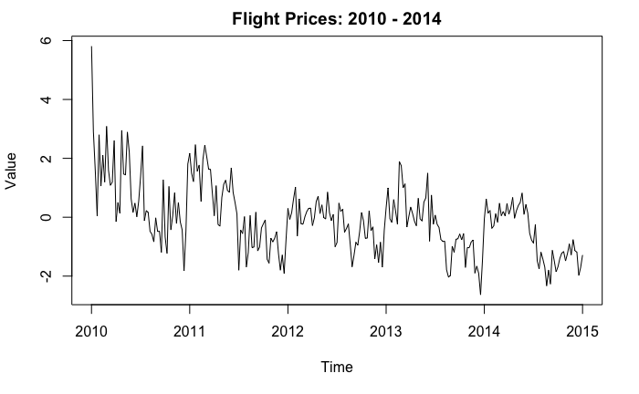

```r
# EDA
#par(mfrow=c(2,2))
plot(tr_2010_2014, main='Flight Prices: 2010 - 2014', ylab='Value')
```

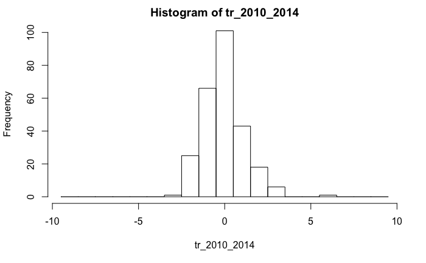

```r
hist(tr_2010_2014, breaks=seq(-9.5, 9.5, by=1))
```

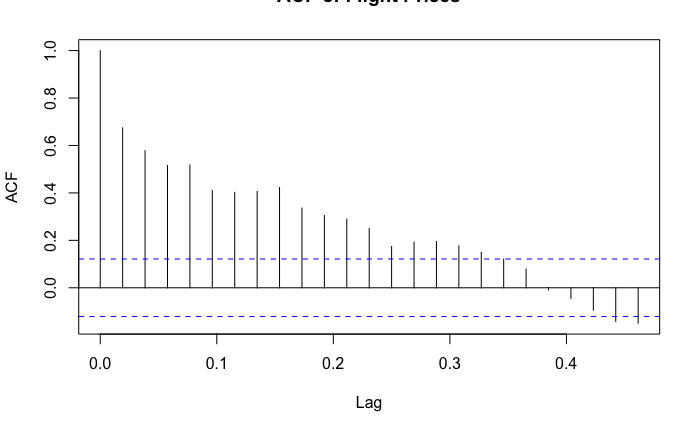

```r
acf(tr_2010_2014, main='ACF of Flight Prices')
```

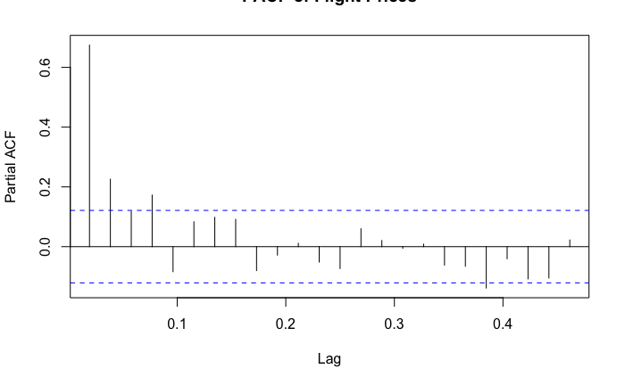

```r
pacf(tr_2010_2014, main='PACF of Flight Prices')
```

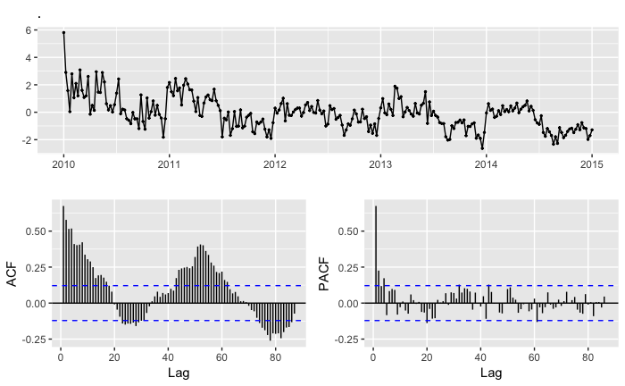

```r
tr_2010_2014 %>% ggtsdisplay()
```

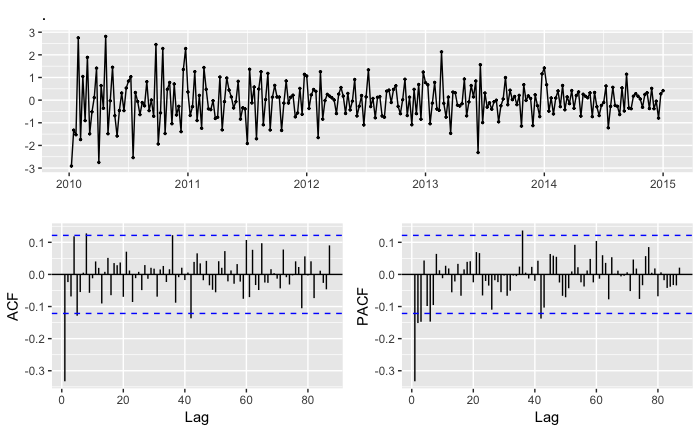

```r
tr_2010_2014 %>% diff(1) %>% ggtsdisplay()
```

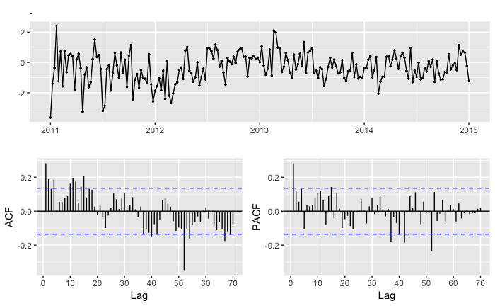

```r
tr_2010_2014 %>% diff(52) %>% ggtsdisplay()
```

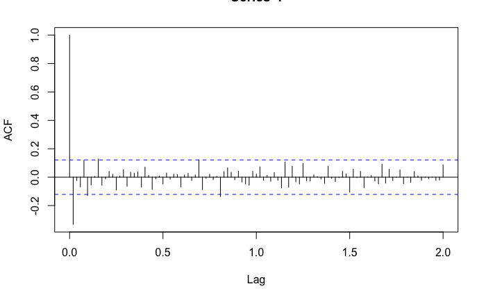

```r
tr_2010_2014 %>% diff() %>% acf(lag=104)
```

**Note that I generally would not model SARIMA like that. However, I just want to illustrate the consequence of ignoring certain patterns of the series.**

# Modeling the non-seasonal component

First, let’s model the non-seasonal component of the raw series. In order to do that, we are going to use the `Arima()` function in the forecast package. I am making the extra steps of modeling the non-seasonal component as pure AR and MA processes first, for illustrative purposes. Based on the ACF and PACF charts, I expect that we can model the non-seasonal component with an ARIMA(0,1,1) or ARIMA(0,1,2).

> Professors Hyndman and Athanasopoulos points out that arima() in R can also be used to estimate an ARIMA model, but it does not allow for the constant c unless d=0, does not return everything required for the forecast() function, and does not allow the estimated model to be applied to new data (which is useful for checking forecast accuracy). As such, they recommend using Arima() instead.

```r
# Let's start by modeling it as a pure AR process
ts.ar <- Arima(tr_2010_2014, order = c(1,0,0))
summary(ts.ar)
```

```
Series: tr_2010_2014
ARIMA(1,0,0) with non-zero mean

Coefficients:
         ar1     mean
      0.7469  -0.0172
s.e.  0.0455   0.1992

sigma^2 estimated as 0.6813:  log likelihood=-319.67
AIC=645.35   AICc=645.44   BIC=656.04

Training set error measures:
                      ME      RMSE       MAE     MPE     MAPE
Training set -0.02414116 0.8222612 0.6043131 65.9152 197.3423
                  MASE       ACF1
Training set 0.7339949 -0.2434035
```

```
    Ljung-Box test

data:  Residuals from ARIMA(1,0,0) with non-zero mean
Q* = 80.748, df = 50.2, p-value = 0.004029

Model df: 2.   Total lags used: 52.2
```

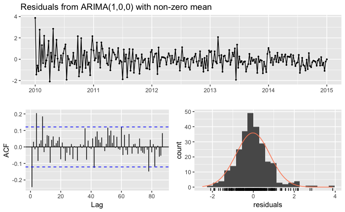

```r
checkresiduals(ts.ar)
```

```r
# Let's model using a pure MA process
ts.ma <- Arima(tr_2010_2014, order=c(0,0,1))
summary(ts.ma)
```

```
Series: tr_2010_2014
ARIMA(0,0,1) with non-zero mean

Coefficients:
         ma1     mean
      0.4942  -0.0608
s.e.  0.0411   0.0896

sigma^2 estimated as 0.9487:  log likelihood=-362.6
AIC=731.2   AICc=731.3   BIC=741.9

Training set error measures:
                       ME     RMSE       MAE     MPE     MAPE
Training set -0.007188033 0.970254 0.7225422 92.6743 153.7135
                  MASE      ACF1
Training set 0.8775953 0.1918342
```

```
    Ljung-Box test

data:  Residuals from ARIMA(0,0,1) with non-zero mean
Q* = 428.43, df = 50.2, p-value < 2.2e-16

Model df: 2.   Total lags used: 52.2
```

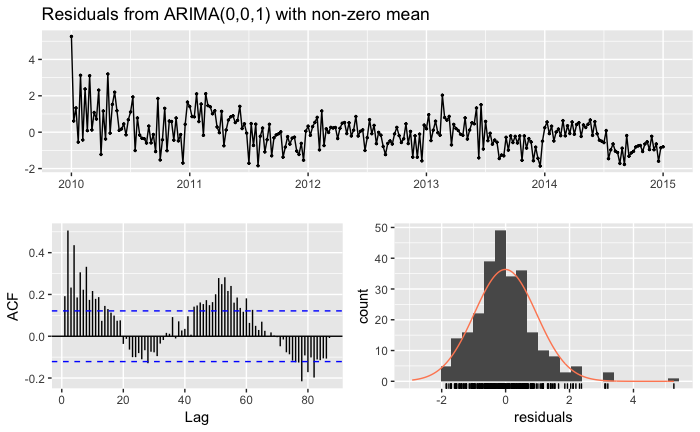

```r
checkresiduals(ts.ma)
```

```r
# Let's look at some ARIMA models
ts.arima <- Arima(tr_2010_2014, order=c(0,1,1))
summary(ts.arima)
```

```
Series: tr_2010_2014
ARIMA(0,1,1)

Coefficients:
          ma1
      -0.5240
s.e.   0.0699

sigma^2 estimated as 0.635:  log likelihood=-309.55
AIC=623.1   AICc=623.15   BIC=630.22

Training set error measures:
                      ME      RMSE       MAE      MPE     MAPE
Training set -0.05344978 0.7938181 0.5949837 6.851986 230.1725
                  MASE       ACF1
Training set 0.7226635 0.08578263
```

```
    Ljung-Box test

data:  Residuals from ARIMA(0,1,1)
Q* = 67.992, df = 51.2, p-value = 0.05814

Model df: 1.   Total lags used: 52.2
```

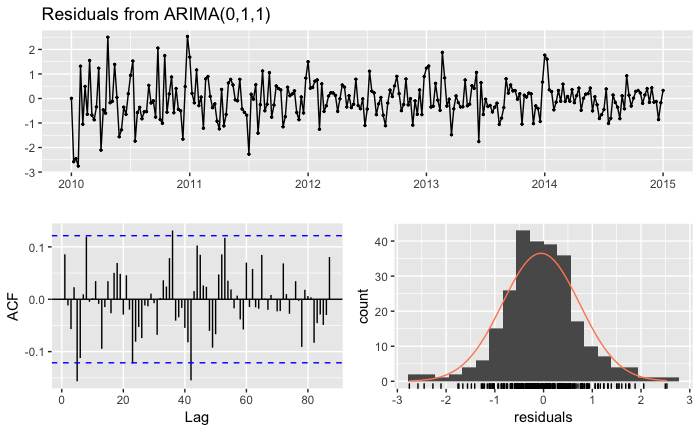

```r
checkresiduals(ts.arima)
```

```r
# Let's look at some ARIMA models
ts.arima2 <- Arima(tr_2010_2014, order=c(0,1,2))
summary(ts.arima2)
```

```
Series: tr_2010_2014
ARIMA(0,1,2)

Coefficients:
          ma1      ma2
      -0.4888  -0.1195
s.e.   0.0621   0.0625

sigma^2 estimated as 0.629:  log likelihood=-307.84
AIC=621.69   AICc=621.78   BIC=632.37

Training set error measures:
                      ME      RMSE       MAE      MPE     MAPE
Training set -0.06159602 0.7885146 0.5924847 7.544857 226.2096
                  MASE       ACF1
Training set 0.7196282 0.03910778
```

```
    Ljung-Box test

data:  Residuals from ARIMA(0,1,2)
Q* = 58.801, df = 50.2, p-value = 0.1896

Model df: 2.   Total lags used: 52.2
```

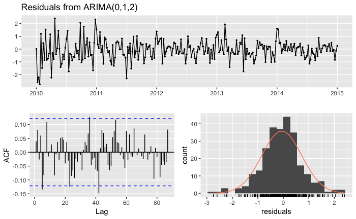

```r
checkresiduals(ts.arima2)
```

# Breakout Session: Modeling the seasonal component

In your group, try to find appropriate values for P and Q. For now, set p,d,q to 0,1,1 respectively, but keep in mind that we might have to change our values for p and q after we add the seasonal component!

```r
# YOUR CODE HERE
ts.season <- Arima(tr_2010_2014, order = c(0,1,1), seasonal= c(1,0,0))
summary(ts.season)
```

```
Series: tr_2010_2014
ARIMA(0,1,1)(1,0,0)[52]

Coefficients:
          ma1    sar1
      -0.5810  0.1861
s.e.   0.0734  0.0802

sigma^2 estimated as 0.6201:  log likelihood=-306.91
AIC=619.83   AICc=619.92   BIC=630.51

Training set error measures:
                      ME      RMSE       MAE      MPE     MAPE
Training set -0.05058931 0.7829077 0.5908358 17.42845 235.3316
                  MASE       ACF1
Training set 0.7176255 0.09818725
```

```
    Ljung-Box test

data:  Residuals from ARIMA(0,1,1)(1,0,0)[52]
Q* = 70.48, df = 50.2, p-value = 0.031

Model df: 2.   Total lags used: 52.2
```

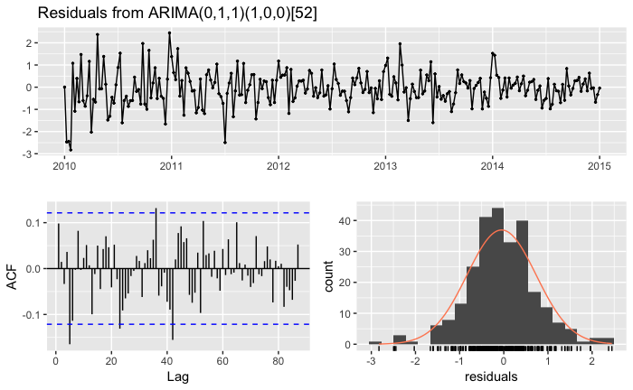

```r
checkresiduals(ts.season)
```

[output not shown]

Arima(tr_2010_2014, order = c(0,2,4), seasonal= c(1,0,1)) = 622 Arima(tr_2010_2014, order = c(0,2,5), seasonal= c(1,0,1)) = 622 Arima(tr_2010_2014, order = c(0,2,3), seasonal= c(1,0,1)) = 622 Arima(tr_2010_2014, order = c(0,2,2), seasonal= c(1,0,1)) = 622 Arima(tr_2010_2014, order = c(0,1,1), seasonal= c(1,0,1)) = 615 Arima(tr_2010_2014, order = c(0,1,1), seasonal= c(1,0,2)) = 616 Arima(tr_2010_2014, order = c(0,1,1), seasonal= c(2,0,2)) = 618

```r
# YOUR CODE HERE
ts.season <- Arima(tr_2010_2014, order = c(5,0,4), seasonal= c(1,0,2))
summary(ts.season)
```

```
Series: tr_2010_2014
ARIMA(5,0,4)(1,0,2)[52] with non-zero mean

Coefficients:
         ar1      ar2     ar3     ar4      ar5     ma1     ma2      ma3      ma4    sar1
      0.0943  -0.0217  0.3691  0.7488  -0.2784  0.3400  0.3278  -0.1583  -0.5812  0.5230
s.e.  0.2143   0.1174  0.1207  0.1649   0.1074  0.2063  0.1113   0.1681   0.1285  0.2144
         sma1    sma2    mean
      -0.3755  0.2157  0.1403
s.e.   0.2220  0.1087  0.6530

sigma^2 estimated as 0.5547:  log likelihood=-293.56
AIC=615.13   AICc=616.83   BIC=665.03

Training set error measures:
                      ME      RMSE       MAE      MPE     MAPE      MASE        ACF1
Training set -0.07157536 0.7259663 0.5501635 44.86754 196.5601 0.6682251 -0.03242138
```

```r
#checkresiduals(ts.season)
```

-write loop for p, d, q and PDQ -go up to 5 for non seasonal - turn off differencing for now - examine residuals for white noise; then look for model w lowest AIC - do forecast for 2015

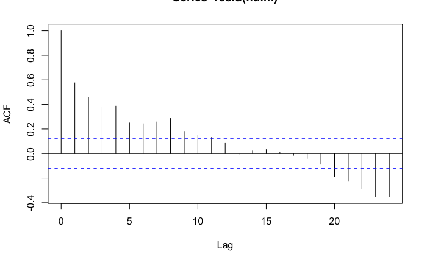

```r
flt.lm <- lm(tr_2010_2014 ~ time(tr_2010_2014))
acf(resid(flt.lm))
```

```r
find.best <- c(0,0,0)
best.aic <- Inf
for (i in 0:5) for (j in 0:4) {
  fit.aic <- AIC(arima(resid(flt.lm), order = c(i,0,j)))
  if (fit.aic <- best.aic) {
    best.order <- c(i,0,j)
    best.arma <- arima(resid(flt.lm), order = best.order)
    best.aic <- fit.aic
  }
}
```

[output not shown]

```r
best.order
```

```
[1] 5 0 4
```

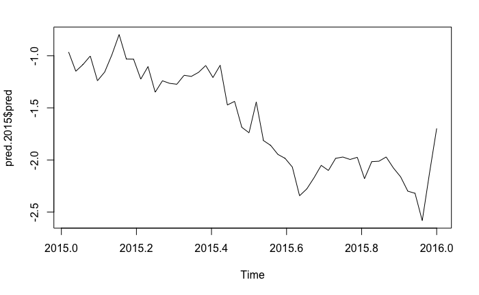

```r
#ts.season > Arima fitted w season
pred.2015 <- predict(ts.season, n.ahead = 52)
plot(pred.2015$pred)
```

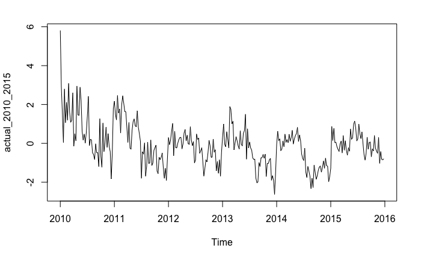

```r
actual_2010_2015 <- ts(d$flight.prices, frequency = 52, start = c(2010,1), end=c(2015,52))
plot(actual_2010_2015)
```